# Bellabeat: Case Study

Patrícia Santos

2024-05-13

## Background Information

**Bellabeat** is a high-tech company that manufactures health-focused smart products. Collecting data on activity, sleep, stress, and reproductive health has allowed Bellabeat to empower women with knowledge about their own health and habits.

### Stakeholders

- Urška Sršen - Bellabeat cofounder and Chief Creative Officer
- Sando Mur - Bellabeat cofounder and key member of Bellabeat executive team
- Bellabeat Marketing Analytics team

### Business Task

Identify trends in the usage of smart devices to discover potential opportunities to improve the Bellabeat marketing strategy.

### About the Data

The data used in this case study can be found [here](https://www.kaggle.com/datasets/arashnic/fitbit?source=post_page-----c18835475563--------------------------------)

These datasets were made available through Mobius in Kaggle. Licensed under the CCO Public Domain. It’s an open source data. According to the information available on Zenodo.org, these datasets where generated by respondents to a distributed survey via Amazon Mechanical Turk between 03.12.2016 and 05.12.2016. Contains personal tracker data from thirty eligible Fitbit users, including minute-level output for physical activity, heart rate, and sleep monitoring.

### Data Organization and Credibility

Available for download are 18 CSV files. Each document has different quantitative data tracked by Fitbit. The data is stored in long format with each ID having data in multiple rows, since data is tracked by day and time.

By sorting and filtering with Pivot Tables in Excel I verified that the data does not pass the integrity and credibility test. Zenodo.org informs us that we have 30 eligible Fitbit users consented to the submission of data, when in reality we can find 33 users in the dataset. Also stated was a timeframe between 03.12.2016 and 05.12.2016 but we only have 31 days represented. Another problem is that the dataset is not current.

The sample size presents a bias. If we had a larger sample size it would have been more representative of the population. It does not have any demographic information such as gender or age and it makes it impossible to understand if it is a true representation.

This will impact any recommendations provided after the analysis.

## Data Preparation

After checking each dataset information, for this analysis, I will be using the following datasets: - daily_activity_merged - hourlysteps_merged - sleep_day_merged

Weight and Heart Rate were not considered due to the small sample presented (8 and 7 users).

The cleaning and analysis of the data was done in R due to accessibility and ability to provide visualizations so I can share my results.

##### 1. Installing packages

```r
install.packages("tidyverse", repos = "http://cran.us.r-project.org")
library(tidyverse)
install.packages("here", repos = "http://cran.us.r-project.org")
library(here)
install.packages("skimr", repos = "http://cran.us.r-project.org")
library(skimr)
install.packages("janitor", repos = "http://cran.us.r-project.org")
library(janitor)
install.packages("lubridate", repos = "http://cran.us.r-project.org")
```

```r
library(lubridate)
install.packages("ggplot2", repos = "http://cran.us.r-project.org")
library(ggplot2)
install.packages("dplyr", repos = "http://cran.us.r-project.org")
library(dplyr)
install.packages("tidyr", repos = "http://cran.us.r-project.org")
library(tidyr)
```

##### 2. Importing the Datasets

```r
daily_activity <- read_csv("Downloads/archive/mturkfitbit_export_4.12.16-5.12.16/Fitabase Data 4.12.16-5.12.16/dailyActivity_merged.csv")
hourly_steps <- read_csv("Downloads/archive/mturkfitbit_export_4.12.16-5.12.16/Fitabase Data 4.12.16-5.12.16/hourlySteps_merged.csv")
daily_sleep <- read_csv("Downloads/archive/mturkfitbit_export_4.12.16-5.12.16/Fitabase Data 4.12.16-5.12.16/sleepDay_merged.csv")
```

##### 3. Sorting the Data

```r
n_distinct(daily_activity$Id)
```

```
## [1] 33
```

```r
n_distinct(hourly_steps$Id)
```

```
## [1] 33
```

```r
n_distinct(daily_sleep$Id)
```

```
## [1] 24
```

##### 4. Checking for Duplicates

```r
sum(duplicated(daily_activity))
```

```
## [1] 0
```

```r
sum(duplicated(hourly_steps))
```

```
## [1] 0
```

```r
sum(duplicated(daily_sleep))
```

```
## [1] 3
```

```r
# cleaning 3 duplicates found in the daily_sleep dataset, remaining with 410 unique values after cleaning.
daily_sleep <- daily_sleep %>%
  distinct() %>%
  drop_na()
```

##### 5. Formatting Date and Time Columns

The column with date and time was cleaned on the daily_activity and daily_sleep. We will be turning it into a data type to ensure consistency and make analysis easier later on.

```r
daily_activity$ActivityDate <-as.Date(daily_activity$ActivityDate, format = "%m/%d/%Y")
daily_sleep$SleepDay <-as.Date(daily_sleep$SleepDay, format = "%m/%d/%Y")
```

In the dataset hourly_steps the ActivityHour column string was converted to date time.

```r
hourly_steps<- hourly_steps %>%
    rename(date_time = ActivityHour) %>%
     mutate(date_time = as.POSIXct(date_time,format ="%m/%d/%Y %I:%M:%S %p" , tz=Sys.timezone()))
```

##### Formatting Column Names

```r
daily_activity = rename(daily_activity, date = ActivityDate)
daily_sleep = rename(daily_sleep, date = SleepDay)
```

##### View the Datasets

```r
head(daily_activity)
```

```
## # A tibble: 6 × 15
##           Id date       TotalSteps TotalDistance TrackerDistance
##        <dbl> <date>          <dbl>         <dbl>           <dbl>
## 1 1503960366 2016-04-12      13162          8.5             8.5
## 2 1503960366 2016-04-13      10735          6.97            6.97
## 3 1503960366 2016-04-14      10460          6.74            6.74
## 4 1503960366 2016-04-15       9762          6.28            6.28
## 5 1503960366 2016-04-16      12669          8.16            8.16
## 6 1503960366 2016-04-17       9705          6.48            6.48
## # ℹ 10 more variables: LoggedActivitiesDistance <dbl>,
## #   VeryActiveDistance <dbl>, ModeratelyActiveDistance <dbl>,
## #   LightActiveDistance <dbl>, SedentaryActiveDistance <dbl>,
## #   VeryActiveMinutes <dbl>, FairlyActiveMinutes <dbl>,
## #   LightlyActiveMinutes <dbl>, SedentaryMinutes <dbl>, Calories <dbl>
```

```r
head(hourly_steps)
```

```
## # A tibble: 6 × 3
##           Id date_time           StepTotal
##        <dbl> <dttm>                  <dbl>
## 1 1503960366 2016-04-12 00:00:00       373
## 2 1503960366 2016-04-12 01:00:00       160
## 3 1503960366 2016-04-12 02:00:00       151
## 4 1503960366 2016-04-12 03:00:00         0
## 5 1503960366 2016-04-12 04:00:00         0
## 6 1503960366 2016-04-12 05:00:00         0
```

```r
head(daily_sleep)
```

```
## # A tibble: 6 × 5
##           Id date       TotalSleepRecords TotalMinutesAsleep TotalTimeInBed
##        <dbl> <date>                 <dbl>              <dbl>          <dbl>
## 1 1503960366 2016-04-12                 1                327            346
## 2 1503960366 2016-04-13                 2                384            407
## 3 1503960366 2016-04-15                 1                412            442
## 4 1503960366 2016-04-16                 2                340            367
## 5 1503960366 2016-04-17                 1                700            712
## 6 1503960366 2016-04-19                 1                304            320
```

## Data Exploration

##### Summary Statistics

First let’s take a look at some summary statistics of the datasets.

```r
# activity
daily_activity %>%
  select(TotalSteps,
              TotalDistance,
            Calories) %>%
    summary()
```

```
##    TotalSteps    TotalDistance       Calories
##  Min.   :    0   Min.   : 0.000   Min.   :   0
##  1st Qu.: 3790   1st Qu.: 2.620   1st Qu.:1828
##  Median : 7406   Median : 5.245   Median :2134
##  Mean   : 7638   Mean   : 5.490   Mean   :2304
##  3rd Qu.:10727   3rd Qu.: 7.713   3rd Qu.:2793
##  Max.   :36019   Max.   :28.030   Max.   :4900
```

```r
# explore number of active minutes per category
daily_activity %>%
  select(VeryActiveMinutes, FairlyActiveMinutes, LightlyActiveMinutes, SedentaryMinutes) %>%
  summary()
```

```
##  VeryActiveMinutes FairlyActiveMinutes LightlyActiveMinutes SedentaryMinutes
##  Min.   :  0.00    Min.   :  0.00      Min.   :  0.0        Min.   :   0.0
##  1st Qu.:  0.00    1st Qu.:  0.00      1st Qu.:127.0        1st Qu.: 729.8
##  Median :  4.00    Median :  6.00      Median :199.0        Median :1057.5
##  Mean   : 21.16    Mean   : 13.56      Mean   :192.8        Mean   : 991.2
##  3rd Qu.: 32.00    3rd Qu.: 19.00      3rd Qu.:264.0        3rd Qu.:1229.5
##  Max.   :210.00    Max.   :143.00      Max.   :518.0        Max.   :1440.0
```

```r
# daily_sleep
daily_sleep %>%
  select(TotalSleepRecords, TotalMinutesAsleep, TotalTimeInBed) %>%
  summary()
```

```
##  TotalSleepRecords TotalMinutesAsleep TotalTimeInBed
##  Min.   :1.00      Min.   : 58.0      Min.   : 61.0
##  1st Qu.:1.00      1st Qu.:361.0      1st Qu.:403.8
##  Median :1.00      Median :432.5      Median :463.0
##  Mean   :1.12      Mean   :419.2      Mean   :458.5
##  3rd Qu.:1.00      3rd Qu.:490.0      3rd Qu.:526.0
##  Max.   :3.00      Max.   :796.0      Max.   :961.0
```

By analyzing this data we can already discover some important information:

• Observing the number of active minutes per category we can see that the sedentary column has the highest average: 991 minutes, or 16 hours.

• Average total steps per day are 7638.

• On average, participants sleep 1 time for 7 hours.

##### Defining Types of Users

For this definition, since we don’t have demographic variables, I will classify our types of users by activity considering their daily number of steps. The categorization will be:

• Sedentary - Less than 5000 steps a day.

• Lightly active - Between 5000 and 7499 steps a day.

• Fairly active - Between 7500 and 9999 steps a day.

• Very active - More than 10000 steps a day.

According to the article that can be found [here](https://www.10000steps.org.au/articles/healthy-lifestyles/counting-steps/).

```r
# finding the daily average number of steps by user

daily_average <- daily_activity %>%
group_by(Id) %>%
summarise (mean_daily_steps = mean(TotalSteps))
```

```r
head(daily_average)
```

```
## # A tibble: 6 × 2
##           Id mean_daily_steps
##        <dbl>            <dbl>
## 1 1503960366           12117.
## 2 1624580081            5744.
## 3 1644430081            7283.
## 4 1844505072            2580.
## 5 1927972279             916.
## 6 2022484408           11371.
```

```r
# Now it’s possible to categorize all of our users

user_type <- daily_average %>%
  mutate(user_type = case_when(
    mean_daily_steps < 5000 ~ "sedentary",
    mean_daily_steps >= 5000 & mean_daily_steps < 7499 ~ "low active",
    mean_daily_steps >= 7500 & mean_daily_steps < 9999 ~ "somewhat active",
    mean_daily_steps >= 10000 ~ "active"
  ))
```

```r
head(user_type)
```

```
## # A tibble: 6 × 3
##           Id mean_daily_steps user_type
##        <dbl>            <dbl> <chr>
## 1 1503960366           12117. active
## 2 1624580081            5744. low active
## 3 1644430081            7283. low active
## 4 1844505072            2580. sedentary
## 5 1927972279             916. sedentary
## 6 2022484408           11371. active
```

```r
# Let's check how many users we have in each category
user_category <- user_type %>%
 group_by(user_type) %>%
 summarise(Count = n())
```

```r
head(user_category)
```

```
## # A tibble: 4 × 2
##   user_type       Count
##   <chr>           <int>
## 1 active              7
## 2 low active          9
## 3 sedentary           8
## 4 somewhat active     9
```

Since we can see the users are fairly distributed, we can understand that all kinds of different users wear smart devices from people who are more sedentary to the more active.

##### Steps Throughout the Day

Now we will see when users are more active during their day.

```r
# First the separation of date_time column in the hourly_steps dataset.
hourly_steps <- hourly_steps %>%
  separate(date_time, into = c("date", "time"), sep= " ") %>%
  mutate(date = ymd(date))
```

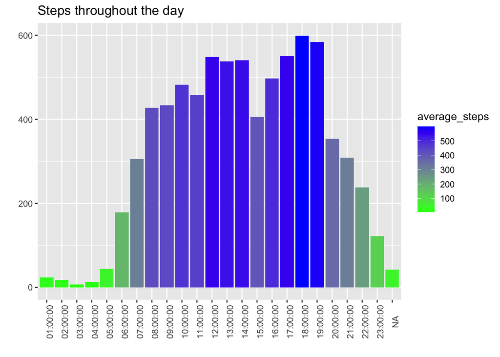

```r
# Now let's visualize it
hourly_steps %>%
 group_by(time) %>%
 summarize(average_steps = mean(StepTotal)) %>%
 ggplot() +
 geom_col(mapping = aes(x=time, y = average_steps, fill = average_steps)) +
 labs(title = "Steps throughout the day", x="", y="") +
 scale_fill_gradient(low = "green", high = "blue")+
 theme(axis.text.x = element_text(angle = 90))
```

We can see that users are more active between 8am and 7pm. Users walk more during lunch time (12pm to 2pm) and then during the evening (5pm to 7pm).

##### Correlation Between Steps and Calories

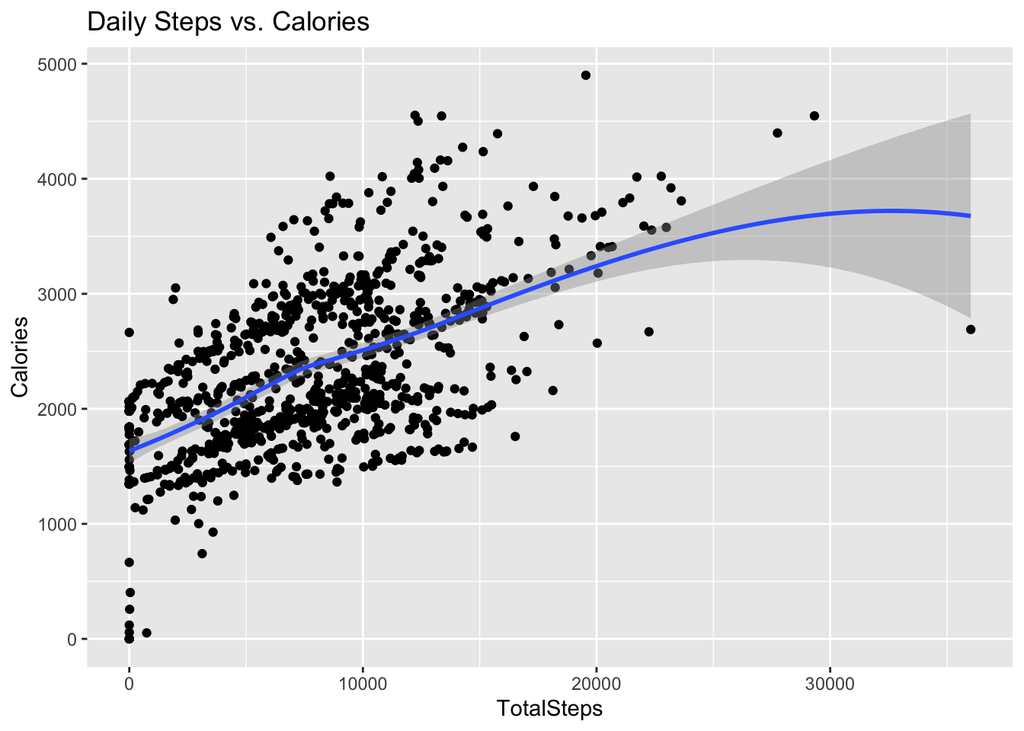

```r
ggplot(data=daily_activity, aes(x=TotalSteps, y=Calories)) +
  geom_point() + geom_smooth() + labs(title="Daily Steps vs. Calories")
```

It’s possible to see a positive correlation between steps and calories burned. As assumed the more steps walked by the users, the more calories they can burn.

##### Correlation Between Time in Bed and Sleep Time

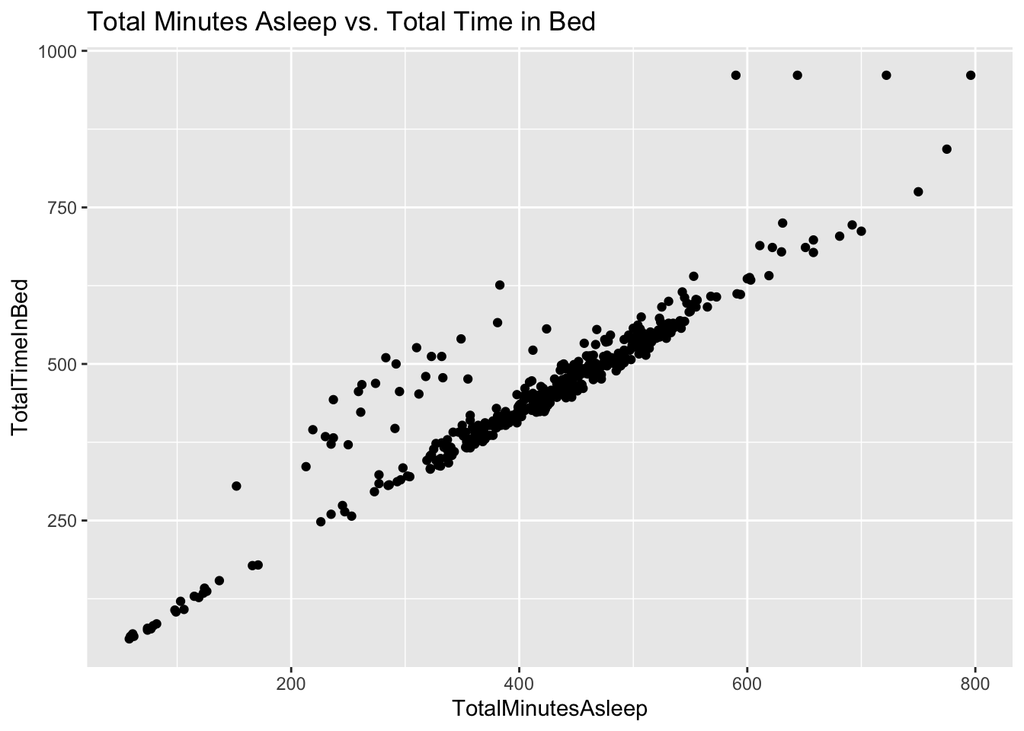

```r
ggplot(data=daily_sleep, aes(x=TotalMinutesAsleep, y=TotalTimeInBed)) +
  geom_point()+ labs(title="Total Minutes Asleep vs. Total Time in Bed")
```

As we can see in the graphic above it’s possible to visualize a linear relationship between total minutes asleep and total time in bed.

##### Relation between User Type and Sleeping Patterns

```r
# First verify the average minutes every user spends sleeping
sleep_pattern <- daily_sleep %>%
  group_by(Id) %>%
  summarise (mean_daily_sleep = mean(TotalMinutesAsleep))
```

```r
head(sleep_pattern)
```

```
## # A tibble: 6 × 2
##           Id mean_daily_sleep
##        <dbl>            <dbl>
## 1 1503960366             360.
## 2 1644430081             294
## 3 1844505072             652
## 4 1927972279             417
## 5 2026352035             506.
## 6 2320127002              61
```

```r
# Now we will classify three different sleeping patterns types
sleep_by_usertype <- sleep_pattern %>%
  mutate(sleep_by_usertype = case_when(
  mean_daily_sleep < 360 ~ "Bad Sleep",
  mean_daily_sleep > 360 & mean_daily_sleep <= 480 ~ "Normal Sleep",
  mean_daily_sleep > 480 ~ "Over Sleep"))
```

```r
head(sleep_by_usertype)
```

```
## # A tibble: 6 × 3
##           Id mean_daily_sleep sleep_by_usertype
##        <dbl>            <dbl> <chr>
## 1 1503960366             360. Normal Sleep
## 2 1644430081             294  Bad Sleep
## 3 1844505072             652  Over Sleep
## 4 1927972279             417  Normal Sleep
## 5 2026352035             506. Over Sleep
## 6 2320127002              61  Bad Sleep
```

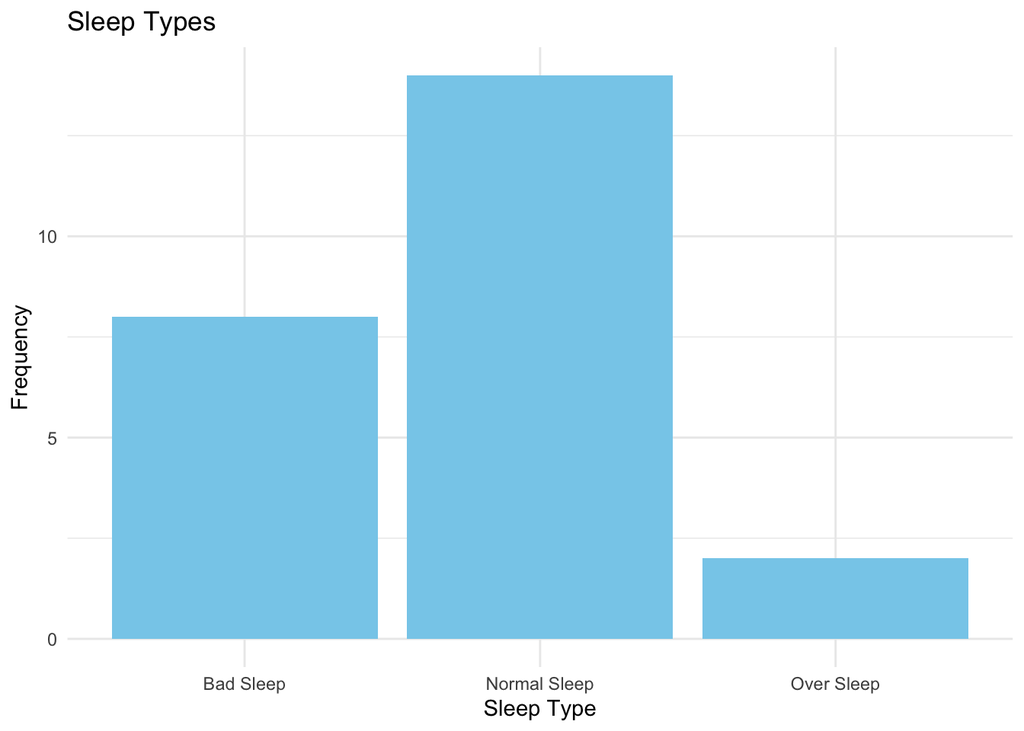

```r
# Now to understand an average of the amount of sleep everyone is getting, let’s count the frequency of each sleep_type
sleep_type_counts <- sleep_by_usertype %>%
 group_by(sleep_by_usertype) %>%
 summarise(count = n())

#Now to visualize it
ggplot(sleep_type_counts, aes(x = sleep_by_usertype, y = count)) +
  geom_bar(stat = "identity", fill = "skyblue") +
  labs(title = "Sleep Types",
   x = "Sleep Type",
   y = "Frequency") +
   theme_minimal()
```

It’s possible to verify that the largest group of users have a normal sleeping pattern.

To further the analysis it’s necessary to understand the relationship between sleeping pattern and user_type. Remember that user_type was defined by the amount of steps given in average.

```r
# First it's necessary to join information from daily_activity and daily_sleep
merged <- merge(sleep_by_usertype, user_type, by=c('Id'))

# To count the frequency of each combination of user_type and sleep_type
sleep_type_counts <- merged %>%
  group_by(user_type, sleep_by_usertype) %>%
  summarise(count = n())
```

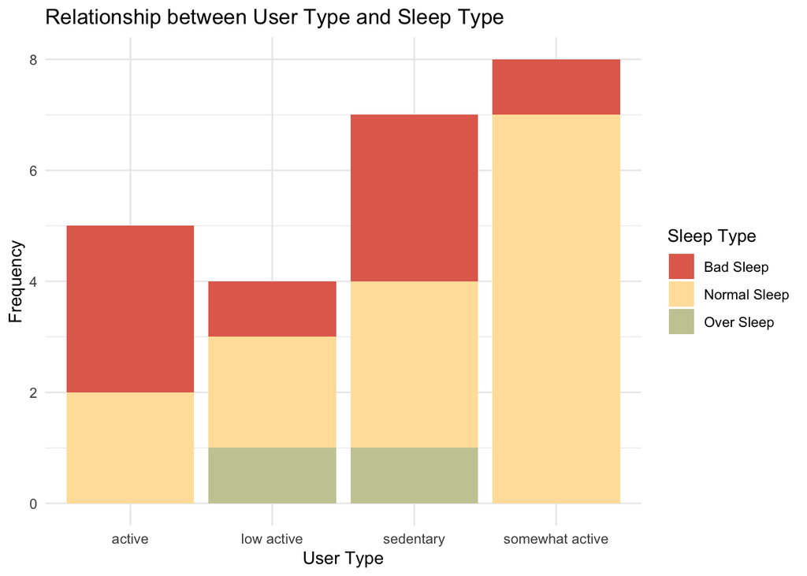

```r
# Define custom colors for visualization
custom_colors <- c("#e26d5c", "#ffe1a8", "#c9cba3")

# Now, create a stacked bar plot with custom colors
ggplot(sleep_type_counts, aes(x = user_type, y = count, fill = sleep_by_usertype)) +
  geom_bar(stat = "identity") +
  labs(title = "Relationship between User Type and Sleep Type",
       x = "User Type",
       y = "Frequency",
       fill = "Sleep Type") +
  scale_fill_manual(values = custom_colors) + # Setting custom colors
  theme_minimal()
```

##### Days Using Smart Devices

In this next step, we want to verify how often do the users use their device.

```r
# First to know how often each ID was logged in/ how often they wore their devices.
id_counts <- daily_activity %>%
  group_by(Id) %>%
  summarise(count = n())

head(id_counts)
```

```
## # A tibble: 6 × 2
##           Id count
##        <dbl> <int>
## 1 1503960366    31
## 2 1624580081    31
## 3 1644430081    30
## 4 1844505072    31
## 5 1927972279    31
## 6 2022484408    31
```

The results show us that daily activity for each user ranged from 4 to 31 times, so to classify their activities

• high use - users between 21 and 31 days.

• moderate use - users between 10 and 20 days.

• low use - users between 1 and 10 days.

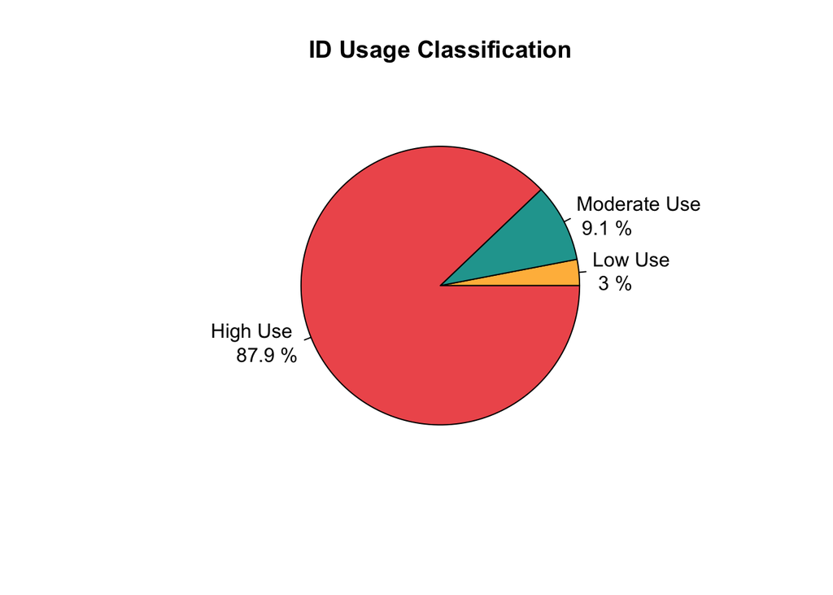

```r
# Add a column for the classification
id_counts$class <- cut(id_counts$count, breaks = c(0, 10, 20, 31), labels = c("Low Use", "Moderate Use", "High Use"))

# Calculate the percentage of IDs in each category
class_counts <- table(id_counts$class)
class_percentages <- prop.table(class_counts) * 100

# Customize colors for chart
custom_colors <- c("#ffba49", "#20a39e", "#ef5b5b")

#Create pie chart
pie(class_percentages,
    labels = paste(names(class_percentages), "\n", round(class_percentages, 1), "%"),
    main = "ID Usage Classification",
    col = custom_colors)
```

We can now verify than most users fall into the high use category.

## Recommendations

Since it was founded in 2013, Bellabeat has been empowering women with knowledge about their own health and habits.

To respond to our business task and help Bellabeat continue their mission, I would advice to use own tracking data for a more complete analysis. The datasets used have a small sample and don’t have demographic details. Knowing that the main target are young and adult women we should find more trends to be able to create a marketing strategy focused on them.

After analyzing the FitBit Fitness Tracker Data, I found some insights that may help improve the Bellabeat app.

1. Recommendation: Personalized recommendations and experiences.

• Description: Users were found to be more active at lunch time and evenings (between 5pm and 7pm). The evening hours, probably, represent the hours after work that people go to the gym or for a walk. Bellabeat can use this time to provide personalized recommendations and experiences to users, such as customized workout routines. Because, sometimes, people want to do something, but they are lost and don’t know exactly what they should be doing. With this we could help motivate users to do a workout designed for them, having their experience and interests in mind.

2. Recommendation: Community challenges.

• Description: Some people won’t get motivated just by getting a simple notification. So, Bellabeat can create engaging activity challenges with all the community that encourage users to stay more active during the day and reach their fitness goals. A gamification system could be incorporated, consisting in reaching different levels based on the number of steps taken per day. Users would get rewards or incentives for completing challenges.

3. Recommendation: Educational content for sleep improvement.